# Analyzing Retweet Dynamics of German MPs in the 19th Legislative Period

Assignment 2: Data Analysis Exercise

Author

Lukas Warode

```r
library(tidyverse)
library(igraph)
library(tidygraph)
library(ggraph)
```

## Load and Manipulate Dataset

In my Master’s Thesis, I scale German MPs (MdBs) of the 19th legislative period across ideological dimensions that are determined in an unsupervised way by using parliamentary speeches and **Tweets**. While `retweet` dynamics do not play a big role in the scaling algorithm per se, party affiliation does and is particularly interesting for network analytical approaches, especially in the realm of clustering.

```r
tweet_df_final <- readRDS("data/tweet_df_final_2.rds")

# further meta information
od_tw_info <- read_csv("data/od_tw_merge_final.csv")
```

How many Tweets are there in total? Over 1.3 Million - quite a lot.

```r
tweet_df_final %>%
  nrow()
```

```
[1] 1301427
```

How many Twitter users are there in total across all MPs of the 19th legislative period?

```r
tweet_df_final %>%
  select(author_id, tw_id) %>%
  distinct() %>%
  nrow()
```

```
[1] 515
```

### Create `data.frame` that exhibits information of referenced `Tweets`

```r
retweet_df <- tweet_df_final %>%
  select(referenced_tweets, tweet_type_character, tweet_type_final, id) %>%
  mutate(
    # type of referenced tweet
    ref_tweet_types = map(1:length(referenced_tweets),
                          ~ referenced_tweets[[.x]][["type"]]),
    # id of referenced tweet (NOT id of user)
    ref_tweet_id = map(1:length(referenced_tweets),
                       ~ referenced_tweets[[.x]][["id"]])
  )
```

### Get author information of `Tweets` that were referenced

```r
author_id_ref_tweet <- retweet_df %>%
  filter(ref_tweet_types == "retweeted") %>%
  mutate(ref_tweet_id = unlist(ref_tweet_id)) %>%
  left_join(
    tweet_df_final %>% select(id, author_id, tw_id),
    by = c("ref_tweet_id" = "id")
  ) %>%
  filter(!is.na(author_id), !is.na(tw_id)) %>%
  select(id, ref_tweet_id, author_id, author_id, tw_id)
```

### Create final `data.frame` that only consists of `retweets` that occured within the dataset

Filter for `retweets` and merge author information from `retweeted` `Tweets`.

```r
# vector with IDs from Tweets that are from authors within the dataset
tweet_ids <- tweet_df_final$id

retweet_within_df <- retweet_df %>%
  filter(ref_tweet_types == "retweeted") %>%
  filter(ref_tweet_id %in% tweet_ids) %>%
  left_join(tweet_df_final %>% select(id, author_id, tw_id)) %>%
  # directedness: from (orginal tweet) -> to (retweeted tweet)
  left_join(author_id_ref_tweet, by = "id", suffix = c("_to", "_from"))
```

How many Tweets are left after constructing the “within-`retweet` `data.frame`? Just about 100000 or 7.7% of all Tweets.

```r
retweet_within_df %>% nrow()
```

```
[1] 100311
```

```r
paste0((nrow(retweet_within_df) / nrow(tweet_df_final) * 100) %>% round(1), "%")
```

```
[1] "7.7%"
```

### Validate Retweet-Network Structure

```r
retweet_within_df %>% select(tw_id_from, tw_id_to) %>% head(5)
```

```
      tw_id_from       tw_id_to
1   katjakipping dorisachelwilm
2    victorperli dorisachelwilm
3  niemamovassat dorisachelwilm
4 michel_brandt_ dorisachelwilm
5 dietmarbartsch dorisachelwilm
```

This makes actually sense! Doris Achelwilm (MP from Left Party) retweets Katja Kipping and Dietmar Bartsch, which do both play a central role in the Left Party: They were party leaders in the 19th legislative period.

### Plot most `retweeted` MPs

First, let us create a vector with party colors.

```r
party_colors <- c("#138BD8", "#000000", "#FFEE0A", "#529222", "#AE1862", "#E30019")
names(party_colors) <- c("AfD", "CDU/CSU", "FDP", "Grüne", "DIE LINKE.", "SPD")
```

We also create a `ggplot2` theme, which is based on `theme_bw()`, but has some refinements.

```r
theme_custom <- function() {
  font <- "Corbel"
  # base theme
  theme_bw() %+replace%
    theme(
      text = element_text(family = font),
      legend.text = element_text(size = 9),
      legend.title = element_blank(),
      legend.box.background = element_rect(
        colour = "black",
        fill = "white",
        linetype = "solid"
      ),
      # grid lines
      panel.grid.major = element_line(color = "grey60", size = 0.2),
      panel.grid.minor = element_line(color = "grey80", size = 0.1),
      # faceting
      strip.background = element_blank(),
      strip.text = element_text(color = "black"),
    )
}
```

Now, we set the new theme as default.

```r
theme_set(theme_custom())
```

We also create a `data.frame` that just includes the party affiliation per MP.

```r
party_user <- tweet_df_final %>%
  distinct(tw_id, party)
```

#### Plot Top 20

Now, we count how often per MP a `Tweet` was `retweeted` by another MP. We plot the to 20 MPs in total and visualize the party affiliation.

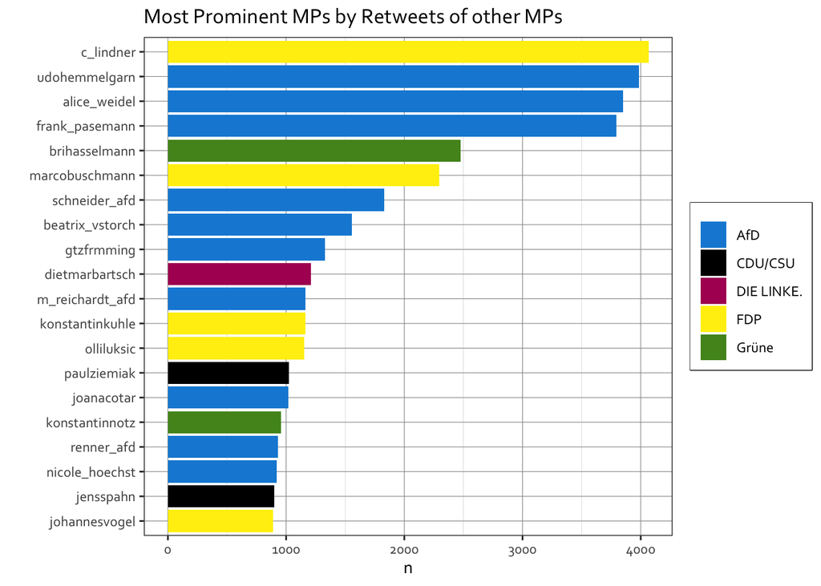

```r
retweet_within_df %>%
  group_by(tw_id_from) %>%
  count() %>%
  ungroup() %>%
  arrange(desc(n)) %>%
  top_n(20) %>%
  left_join(party_user, by = c("tw_id_from" = "tw_id")) %>%
  ggplot(aes(x = n, y = reorder(tw_id_from, n), fill = party)) +
  geom_col() +
  scale_fill_manual(values = party_colors) +
  labs(y = "", title = "Most Prominent MPs by Retweets of other MPs")
```

Interestingly, the AfD and FDP dominate the chart, while there is no single SPD MP within the top 20 most retweeted MPs within. Let’s check the pattern and plot by party! Overall, the results seem to make sense, given that party leaders and influential MPs are the most retweeted MPs according to the bar plot.

#### Plot Top 20 by Party

Now, let’s turn the attention to the most retweeted MPs by party. Both CDU/CSU and SPD, the biggest parties and also only members of the governing coalition of the 19th legislative period do not have as many influential MPs, measured by number of retweets across their colleagues, as opposition parties have.

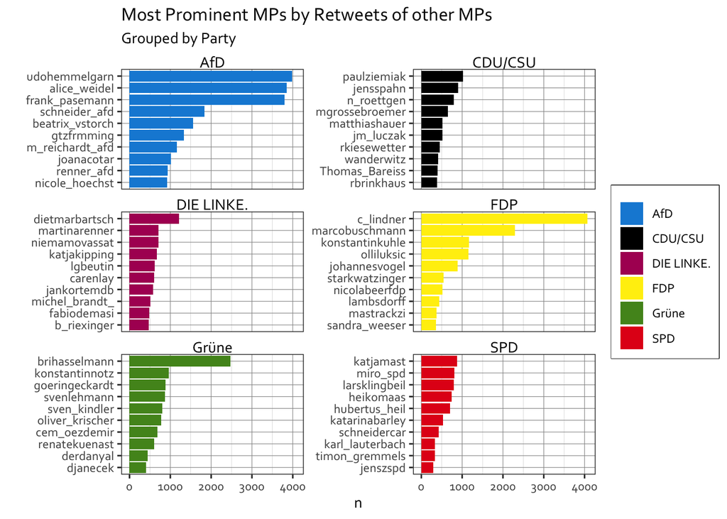

```r
retweet_within_df %>%
  left_join(party_user, by = c("tw_id_from" = "tw_id")) %>%
  filter(!party %in% c("Fraktionslos", NA)) %>%
  group_by(tw_id_from, party) %>%
  count() %>%
  group_by(party) %>%
  arrange(desc(n)) %>%
  top_n(10) %>%
  ggplot(aes(x = n, y = reorder(tw_id_from, n), fill = party)) +
  geom_col() +
  facet_wrap(~ party, scales = "free_y", ncol = 2) +
  scale_fill_manual(values = party_colors) +
  labs(y = "", title = "Most Prominent MPs by Retweets of other MPs", subtitle = "Grouped by Party")
```

## Construct Retweet-Network

In a Retweet-Network each `retweet` is represented as a directed link in a network that connects **from** the `original Tweet` **to** the referenced `retweet`. Users that are often `retweeted` within the network are expected to be associated with some degree of (digital) political relevance, even though there a lot of potential confounding variables (e.g. number of Tweets, number of Followers, general social media behaviour and association with socio-demographic factors such as cohort affiliation).

```r
retweet_network <- retweet_within_df %>%
  select(from = tw_id_from, to = tw_id_to) %>%
  as_tbl_graph(directed = TRUE) %N>%
  left_join(party_user, by = c("name" = "tw_id"))
```

## Degree Centrality

### Out-degree

In the previous plots, we already calculated the out-degree centrality (which is the same as the number of outgoing edges per node or the number of `original Tweets` that have been `retweeted` within). Nevertheless, double-checking is always a good practice!

```r
# %N>% activate nodes (tidygraph syntax)
retweet_network %N>%
  mutate(
    in_degree = centrality_degree(mode = "in"),
    out_degree = centrality_degree(mode = "out")
  ) %>%
  arrange(desc(out_degree)) %>%
  select(name, out_degree) %>%
  as_tibble() %>%
  head(20)
```

```
# A tibble: 20 × 2
   name            out_degree
   <chr>                <dbl>
 1 c_lindner             4066
 2 udohemmelgarn         3983
 3 alice_weidel          3853
 4 frank_pasemann        3794
 5 brihasselmann         2475
 6 marcobuschmann        2294
 7 schneider_afd         1830
 8 beatrix_vstorch       1554
 9 gtzfrmming            1330
10 dietmarbartsch        1208
11 m_reichardt_afd       1164
12 konstantinkuhle       1162
13 olliluksic            1154
14 paulziemiak           1022
15 joanacotar            1021
16 konstantinnotz         956
17 renner_afd             933
18 nicole_hoechst         921
19 jensspahn              901
20 johannesvogel          888
```

### In-degree

The in-degree corresponds to the “inverse retweet behaviour”: It indicates which MPs retweeted Tweets of other MPs.

```r
# %N>% activate nodes (tidygraph syntax)
retweet_network %N>%
  mutate(
    in_degree = centrality_degree(mode = "in"),
    out_degree = centrality_degree(mode = "out")
  ) %>%
  arrange(desc(in_degree)) %>%
  select(name, in_degree) %>%
  as_tibble() %>%
  top_n(20)
```

```
# A tibble: 20 × 2
   name            in_degree
   <chr>               <dbl>
 1 udohemmelgarn        6002
 2 schneider_afd        5001
 3 frank_pasemann       3583
 4 martinrosemann       3409
 5 renner_afd           3270
 6 olliluksic           2140
 7 nicole_hoechst       1735
 8 drandreasnick        1567
 9 stbrandner           1519
10 rkiesewetter         1505
11 reinholdmdb          1494
12 c_jung77             1284
13 k_sa                 1225
14 elsnervongronow      1187
15 tschipanski          1006
16 ullinissen            991
17 andi_wagner           969
18 gtzfrmming            868
19 djanecek              834
20 steinekecdu           807
```

### Comparing Out- and In-degree

In- and out-degree seem to be correlated ($R = 0.53$), however, there are outliers that influence the relationship heavily.

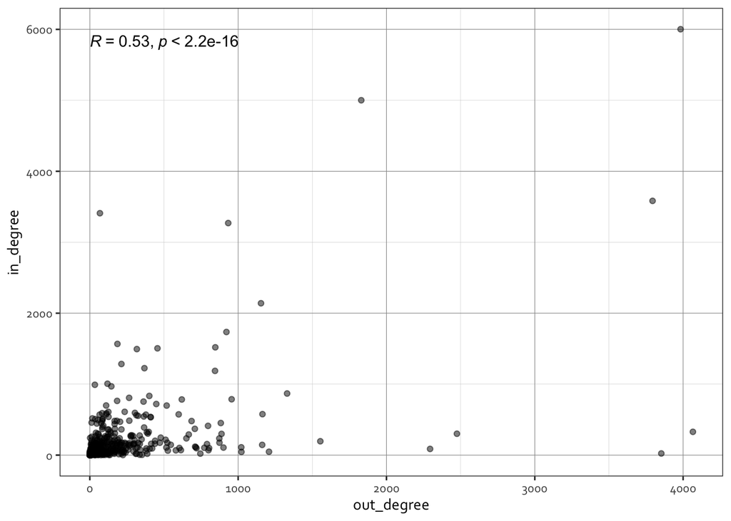

```r
# %N>% activate nodes (tidygraph syntax)
retweet_network %N>%
  mutate(
    in_degree = centrality_degree(mode = "in"),
    out_degree = centrality_degree(mode = "out")
  ) %>%
  select(name, in_degree, out_degree) %>%
  as_tibble() %>%
  left_join(party_user, by = c("name" = "tw_id")) %>%
  ggplot(aes(out_degree, in_degree)) +
  geom_point(alpha = 0.5) +
  ggpubr::stat_cor()
```

It seems that there are a few outliers at the upper end of the distribution. Let’s see whether the correlation holds when they are removed.

The correlation is still quite high ($R = 0.38$) and highly significant, when we remove the MPs with the top 20 highest in- and out-degrees.

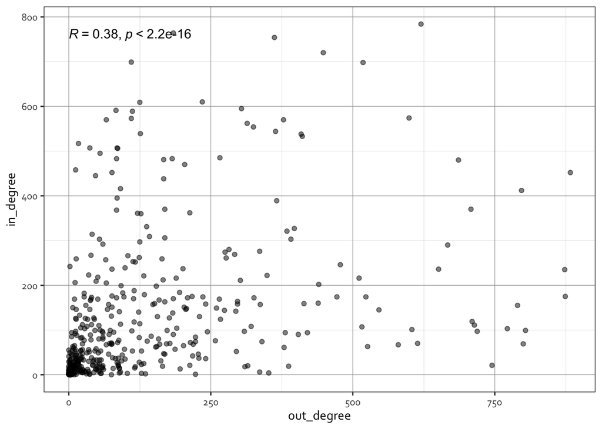

```r
top_20_in <- retweet_network %>%
  mutate(in_degree = centrality_degree(mode = "in")) %>%
  arrange(desc(in_degree)) %>%
  as_tibble() %>%
  top_n(20) %>%
  pull(name)

top_20_out <- retweet_network %>%
  mutate(out_degree = centrality_degree(mode = "out")) %>%
  arrange(desc(out_degree)) %>%
  as_tibble() %>%
  top_n(20) %>%
  pull(name)

# %N>% activate nodes (tidygraph syntax)
retweet_network %N>%
  mutate(
    in_degree = centrality_degree(mode = "in"),
    out_degree = centrality_degree(mode = "out")
  ) %>%
  select(name, in_degree, out_degree) %>%
  as_tibble() %>%
  left_join(party_user, by = c("name" = "tw_id")) %>%
  filter(!name %in% top_20_in, !name %in% top_20_out) %>%
  ggplot(aes(out_degree, in_degree)) +
  geom_point(alpha = 0.5) +
  ggpubr::stat_cor()
```